# Pacific Salmon SAR & SAS Estimator

Author

Kris Warner & Matt Siskey

# Setup

This script uses WDFW hatchery coded wire tag (CWT) release and return data to fit run-specific smolt-adult return (SAR) and smolt-adult-survival (SAS) models for Pacific salmon species. The first chunk below loads libraries, sets directories, and sources any functions required for the analysis. A table is generated that displays species- and system-specific location_code information for the parameters set in the YAML header, including hatchery_location_codes, release_location_codes, and stock_location_codes for data to be used in SAR/SAS calculation. This table is based on a metadata ruleset constructed by the developers, and new queries will require additions to this ruleset for smooth data processing and model fitting.

```r
##############################
### Clear workspace & load libraries
# rm(list=ls())
# Chinook=1; Coho=2; Steelhead=3;
# spring == 1; summer == 2; fall == 3; winter == 4
# First-time rmisr install
# options(download.file.method = "wininet")
# devtools::install_github("MattCallahan-NOAA/rmisr", force=TRUE)

# Load packages, several aren't used in this workflow
pacman::p_load(rmisr, httr, magrittr, dplyr, purrr, stringr, tidyverse, knitr, kableExtra, ggplot2, plotly,
               RColorBrewer, jsonlite, janitor, keyring, mgcv, here, lubridate, tidygam, ggeffects, readr)

# Supply API key through keyring to access RMIS server & maintain credential security
token <- key_get("rmis_api")

##############################
### Set up drives & controls
my_drive    <-paste0("C:/Users/sism1477/OneDrive - Washington State Executive Branch Agencies/")
share_drive <-paste0(my_drive,"DFW-Team FP Westside Hatchery MandE - R/")
proj_drive  <-paste0(share_drive,"psalmon_sar_sas/")
`%nin%`     <-negate(`%in%`) # create an exclude operator
source(paste0(proj_drive,"functions/functions.R",sep="")) #Source functions for use below

fishery_id <-read.csv(paste0(proj_drive,"data/fishery.csv",sep=""))
fishery_id$fishery <-as.character(fishery_id$fishery)
ruleset <-read.csv(paste0(proj_drive,"data/hatchery_program_ruleset.csv",sep=""), fileEncoding = "latin1", check.names=F)

param_tab <-data.frame(params=c("system","species","run","start_yr","end_yr"),
                       value=c(params$system,params$sp,params$run,params$yr_start,params$yr_end))

param_tab %>%
  kbl(format="html", row.names = NA)%>%
  kable_classic(position="left", html_font = "Cambria")%>%
  kable_styling(full_width = F, bootstrap_options = c("condensed")) #%>% pack_rows(index = table(sar_df$brood_year))
ruleset %>%
  filter(., system==params$system) %>%
  # rename("month" = first_release_date_month) %>%
  # arrange(brood_year, month,avg_weight) %>%
  # select(-brood_year)%>%
  kbl(format="html", row.names = NA)%>%
  kable_classic(position="left", html_font = "Cambria")%>%
  kable_styling(full_width = F, bootstrap_options = c("condensed")) #%>% pack_rows(index = table(sar_df$brood_year))
```

Table 1: Query values and the location-based ruleset for the user-defined system.

(a) Parameter values set in the YAML header defining which data are being pulled from RMIS for calculation of SAR and SAS.

| params | value |
| --- | --- |
| system | r5_lewis |
| species | 1 |
| run | 1 |
| start_yr | 2013 |
| end_yr | 2020 |

(b) Species- and system-specific location_code information for the parameters set in the YAML header, including hatchery_location_codes, release_location_codes, and stock_location_codes. This information is used to query RMIS' via API connection, pull relevant data, and run SAR & SAS analyses.

| species | system | loc_code | loc_name | loc_col |
| --- | --- | --- | --- | --- |
| 1 | r5_lewis | 3F42001^^270168^H | LEWIS RIVER HATCHERY | hatchery_location_code |
| 1 | r5_lewis | 3F42001^^270430^H | SPEELYAI HATCHERY | hatchery_location_code |
| 1 | r5_lewis | 3F42001^^270168^R | LEWIS R 27.0168 | release_location_code |
| 1 | r5_lewis | 3F42001^^270168^R01 | LEWIS R -NF 27.0168 | release_location_code |
| 1 | r5_lewis | 3F42001^^270168^R02 | LK MERWIN (27) | release_location_code |
| 1 | r5_lewis | 3F42001^^280159^R | WASHOUGAL R 28.0159 | release_location_code |
| 1 | r5_lewis | 3F42001^^270327^R | JOHNSON CR 27.0327 | release_location_code |
| 1 | r5_lewis | 3F42001^^270339^R | CEDAR CR 27.0339 | release_location_code |
| 1 | r5_lewis | 3F42001^^270173^R | LEWIS R -EF 27.0173 | release_location_code |
| 1 | r5_lewis | 3F42001^^270168^S | LEWIS R 27.0168 | stock_location_code |
| 1 | r5_lewis | 3F42001^^270168^S04 | LEWIS RIVER HATCHERY | stock_location_code |

## Pull data & format

This chunk pulls CWT-based release and recovery data from the Pacific States Marine Fisheries Commission’s (PSMFC) Regional Marking Information System (RMIS) database for the species and hatchery stock set by the user at the top of this script. Release and return data are categorized by release size, release stage, release location, and are uniquely identified by coded-wire-tag codes. The release data are pulled first and length-weight data associated with those releases are used to determine stage-at-release.

To ensure all data employed in SAR/SAS calculations are smolt-release data, the script categorizes releases by stage using a mixture of information reported in the literature and RMIS data queried by the user. Quinn (2018) reports length-at-smolt (mm) by species in Table 15.1, which summarizes data from 218 published and unpublished reports. We use these reported values to inform a release stage designation, where the avg_length and avg_weight fields queried from RMIS by the user are fit to an exponential model and the model fit is used to predict weight-at-smolt. This weight-at-smolt is then used to classify release stages, currently implemented as “smolt” if they are larger than the threshold size calculated or “fry_parr” if smaller than it. Given the query-specific nature of this analysis, if program- or system-specific data on size-at-smolt were available, these data could be used directly to inform release_stage classifications.

```r
### [LOCATION]
loc_all <-get_location(token = token)
# rect <-loc_all |>
#   filter(location_type == 2) #|>
#   rename(recovery_location_name = name,
#      recovery_description = description,
#      recovery_location_code = location_code) |>
#   select(-c(id, format_version, record_code))

### [RELEASES] Pull in RMIS release data
### hatchery of interest location codes, found on the hatt data frame
hatcheries <-unique(filter(ruleset, system == params$system & loc_col == "hatchery_location_code")$loc_code)
# hatcheries <-"3F42001^^260002^H02"
rel_h <-list()

for(h in 1:length(hatcheries)){
  rel_h[[h]] <-rmisr::get_release(token = token,
                        species = params$sp,
                        # release_location_code = params$release_location_code)
                        hatchery_location_code = hatcheries[h])
}
names(rel_h) <-hatcheries
rel_df <-map_df(rel_h, ~as.data.frame(.))


### Assign release stage based on length-at-smolt and length-weight relationship
len_wt_df <-rel_df %>% drop_na(avg_length)
len_wt_df <-len_wt_df[order(len_wt_df$avg_length), ]
len_wt_fit <-lm(log(avg_weight) ~ avg_length, data=len_wt_df)
# summary(len_wt_fit)

if(params$sp==1){smolt_mm <-60} # chinook
if(params$sp==2){smolt_mm <-105} # coho
if(params$sp==3){smolt_mm <-200} # steelhead
if(params$sp==4){smolt_mm <-80} # sockeye
if(params$sp==5){smolt_mm <-40} # chum
if(params$sp==6){smolt_mm <-32} # pink
if(params$sp==8){smolt_mm <-190} # cutthroat

# len_wt_pred <-predict(len_wt_fit, newdata = data.frame(avg_length=smolt_mm))
len_wt_coefs <- coef(len_wt_fit)
a <- as.numeric(exp(len_wt_coefs[1]))  # 'a' is the initial value
r <- as.numeric(len_wt_coefs[2])       # 'r' is the growth/decay rate
len_wt_pred <- a * exp(r * smolt_mm)


rel_dat <-rel_df %>%
  mutate(release_stage_assigned = case_when(
      avg_weight > len_wt_pred ~ "smolt",
      # avg_weight >= 5 ~ "parr",
      avg_weight >= 0 ~ "fry_parr"
    )
  )

cols_to_fix <- c("cwt_1st_mark_count", "cwt_2nd_mark_count", "non_cwt_1st_mark_count", "non_cwt_2nd_mark_count")
rel_dat[cols_to_fix][is.na(rel_dat[cols_to_fix])] <- 0
rel_dat$event_released <-rel_dat$cwt_1st_mark_count +
                         rel_dat$cwt_2nd_mark_count
rel_dat$release_stage_assigned <-as.factor(rel_dat$release_stage_assigned)

rel_agg <-rel_dat %>% filter(!grepl("!",tag_code_or_release_id)) %>%
                      filter(run==params$run) %>%
                      mutate(avg_weight = ifelse(avg_weight < 5, round(avg_weight),round(avg_weight, digits = -1))) %>%
                      mutate(first_release_date = make_date(first_release_date_year, first_release_date_month, first_release_date_day)) %>%
                      mutate(jday = yday(first_release_date)) %>%
                      aggregate(event_released ~ species + brood_year + release_location_code + hatchery_location_code + stock_location_code +
                                                 first_release_date_month + tag_code_or_release_id + jday + avg_weight + release_stage_assigned,
                                data=., FUN=sum) %>%
                      rename(tag_code = tag_code_or_release_id)

if(params$yr_trim=="true"){rel_agg <-filter(rel_agg, brood_year %in% seq(params$yr_start,params$yr_end,1))}
if(params$smolt=="true"){rel_agg <-filter(rel_agg,release_stage_assigned=="smolt")}

##############################
# [RETURNS] Pull in WDFW FishBooks return data
# use the tag codes from the release query to grab recoveries; pull capped at 500k records
rel_agg_cwt <-unique(rel_agg$tag_code)
rec_cwt <-list()

for(t in 1:length(rel_agg_cwt)){
  rec_cwt[[t]] <-get_recovery(token = token, tag_code = rel_agg_cwt[[t]], species = params$sp)
}
names(rec_cwt) <-rel_agg_cwt

rec_cwt_df <-rec_cwt %>% map_df(., ~as.data.frame(.)) %>%
                         mutate(recovery_date = make_date(recovery_date_year, recovery_date_month, recovery_date_day)) %>%
                         mutate(jday_rec = yday(recovery_date)) %>%
                         left_join(., rel_agg[,c("brood_year","tag_code")], by = "tag_code")

rec_cwt_df$age <-rec_cwt_df$recovery_date_year-rec_cwt_df$brood_year

rec_join <-rec_cwt_df %>% filter(., age >= 3) %>%
                          aggregate(number_cwt_estimated ~ species + recovery_location_code + fishery + tag_code, data=., FUN=sum)

# r5_cowlitz strays to:
## 3F42001^^270168^R03 == MERWIN DAM FCF (+10 number_cwt_estimated)
## 3F42001^^270002^H == KALAMA FALLS HATCHERY (+14 number_cwt_estimated)
## 3F42001^^260002^R12 == ABOVE FALLS DAM (cowlitz) (+0 number_cwt_estimated)

########################## Join Release & Return Data for SAR ##########################
# even if release_location_code is the same across recoveries, event_released gets multi-counted if you dont distinguish separate SAR calculations for tag_code
sar_df <-left_join(rel_agg, rec_join[,c("tag_code","number_cwt_estimated","recovery_location_code","fishery")], by = "tag_code") %>%
         aggregate(cbind(event_released, number_cwt_estimated) ~ species + brood_year + release_location_code + hatchery_location_code +
                                                                 first_release_date_month + jday + avg_weight + release_stage_assigned + tag_code +
                                                                 recovery_location_code + fishery,
                   data=., FUN=sum)

sar_df$sar <-sar_df$number_cwt_estimated/sar_df$event_released


####################################
### Length-weight relationship for determining stage
# set plotting theme
theme_set(theme_minimal())

### length-weight relationship of unfiltered data
len_wt <- ggplot(len_wt_df, aes(x=avg_length, y=avg_weight, group=as.factor(first_release_date_month), color=as.factor(first_release_date_month))) +
            # geom_line(aes(x = avg_length, y = prediction*100,group=first_release_date_month), linewidth=1) +
            geom_point(pch=21)+
            geom_vline(xintercept=smolt_mm, color="red",linetype="dashed",alpha=0.3)+
            # facet_wrap(.~run, ncol=1)+
            labs(x="Mean Length (mm)", y="Mean Weight (g)", color="Release Month")
ggplotly(len_wt)
```

[interactive chart not shown]

After stage has been assigned, release data are filtered for CWT-tagged groups (i.e., tag_code_or_release_id beginning with “!” are removed). An event_released column is created by combining cwt_1st_mark_count and cwt_2nd_mark_count, and julian day is calculated from first_release_date. Release counts (“event_released”) are then aggregated by run, brood year, release location, tag code, julian day, weight-at-release, and stage-at-release. Tag code groups that do not have one of these data types are removed, as well as groups that fall outside the brood year window designated in the YAML header. A table is generated below that reports the release_location_code information for the filtered data.

Table 2: Release location information for filtered data used in the following smolt-adult return calculations.

| species | system | loc_code | loc_name | loc_col |
| --- | --- | --- | --- | --- |
| 1 | r5_lewis | 3F42001^^270168^R | LEWIS R 27.0168 | release_location_code |
| 1 | r5_lewis | 3F42001^^270168^R01 | LEWIS R -NF 27.0168 | release_location_code |

# Smolt-adult-return (SAR)

Smolt-adult-return is calculated for each categorized fate (hatchery, fishery, and spawning ground) of paired release-recovery data. Below, fate is categorized based on fishery coding, and then fate-specific SARs are reported. These fate-specific SARs are then used below to: (1) fit predictive SAR models, and (2) calculate smolt-adult-survival (SAS).

## Fate-specific SARs

Fate is determined by the fishery coding reported for each recovery. Fishery codes range from 10-99, with some additional codes supplied for high seas fishery categories (800-812). We designate troll (10-19), net & seine (20-29), aboriginal (30-39), sport (40-49), treaty subsitence (56), test (60-69), and high seas (80-89, 800, 802-805, 812) fisheries recoveries as ‘fishery’ fates. In addition, we designate hatchery (50), fish trap (52), broodstock collections (53), and mixed broodstock collection/hatchery returns (57) recoveies as ‘hatchery’ fates, and we designate spawning ground (54) recoveries as ‘spawngr’ fates.

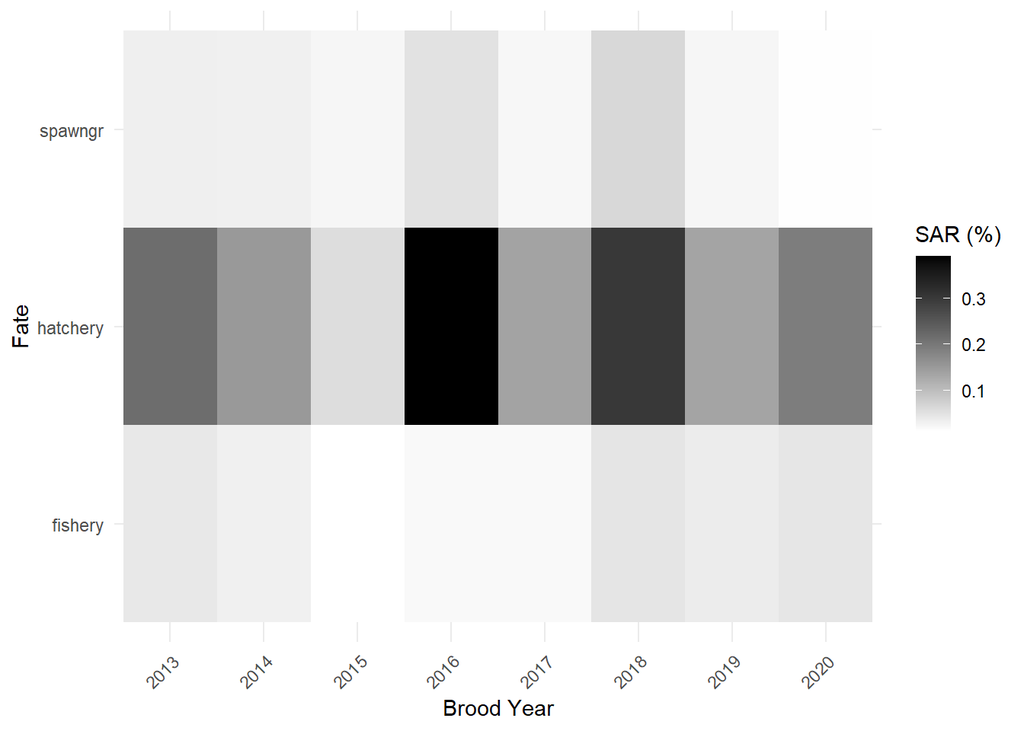

Figure 2: Smolt-adult return calculated collectively across brood year released and recovery fate.

```r
### this is the step where we distinguish fates (sar) & their contribution to sas (collective sar)
### sar by fate category (composed from 'fishery' codes in RMIS, but not all fisheries)
troll        <-seq(10,19,1)
net_seine    <-seq(20,29,1)
aboriginal   <-seq(30,39,1)
sport        <-seq(40,49,1)
esc          <-seq(50,59,1)
test_fishery <-seq(60,69,1)
juv_sampling <-seq(70,79,1) # disregarded
high_sea     <-c(seq(80,89,1),800,802,803,804,805,812)
misc         <-seq(90,99,1) # disregarded

fate_fishery <-c(troll, net_seine, aboriginal, sport, 56, test_fishery, high_sea)
fate_hatchery <-c(50,52,53,57)
fate_spawngr <-54

sar_df_fates <-left_join(sar_df, fishery_id, by = "fishery") %>%
               select(-sar) %>%
               aggregate(cbind(event_released, number_cwt_estimated) ~ species + brood_year + release_location_code + hatchery_location_code +
                                                                       first_release_date_month + jday + avg_weight + release_stage_assigned +
                                                                       recovery_location_code + fishery + fishery_name + fishery_short_name + tag_code,
                         data=., FUN=sum) %>%
               mutate(.,fate = case_when(fishery %in% fate_fishery ~ "fishery",
                                                    fishery %in% fate_hatchery ~ "hatchery",
                                                    fishery %in% fate_spawngr ~ "spawngr"))

sar_df_fates$sar <-sar_df_fates$number_cwt_estimated/sar_df_fates$event_released



### top-level fate returns
# aggregated fate tiles
sar_df_fates %>% select(-sar) %>%
                 aggregate(number_cwt_estimated ~ species + brood_year + fate + tag_code + event_released, data=., FUN=sum) %>%
                 aggregate(cbind(event_released, number_cwt_estimated) ~ species + brood_year + fate, data=., FUN=sum) %>%
                 complete(., species, brood_year, fate, fill = list(event_released = 0, number_cwt_estimated = 0)) %>%
                 ggplot(.,aes(x=as.factor(brood_year),y=as.factor(fate), fill=(number_cwt_estimated/event_released)*100))+
                    geom_tile(linewidth=0.5)+
                    scale_fill_gradient(low = "white", high = "black")+
                    # facet_wrap(.~run, ncol=1)+
                    labs(x = "Brood Year", y = "Fate", fill = "SAR (%)")+
                    theme(axis.text.x = element_text(angle = 45, hjust = 1))

# boxplots of fate time series
# ggplot(sar_df_fates,aes(x=as.factor(brood_year),y=sar*100))+
#    geom_boxplot()+
#    geom_point(pch=21,size=2)+
#    facet_wrap(fate~., ncol=2)+
#    labs(x = "Brood Year", y = "SAR (%)")+
#    theme(axis.text.x = element_text(angle = 45, hjust = 1))
```

**Hatchery SAR**

Paired release-recovery data are filtered for ‘hatchery’ fates in this section, and used to calculate hatchery SARs. We first report the recovery_location_codes present in the filtered data and the estimated recoveries (number_cwt_estimated) for each recovery location. There will likely be strays present, but we want to report a ‘return to rack’ for the hatchery to inform program performance and broodstock collection. Therefore, we filter these stray fish out here, and will re-incorporate them later in the summation of fate-specific SARs for calculation of SAS. Therefore, all hatchery SAR results will be for the list of location_codes categorized as hatchery_location_code in the metadata ruleset (Table 1).

```r
# Plot.rectY(data,
#   Plot.stackY(
#     Plot.binX(
#       {y: "count"},
#       {x: "body_mass_g", fill: "species", thresholds: 20})
#     )
#   ).plot({
#     facet: {
#       data,
#       x: "sex"
#     },
#     marks: [Plot.frame()]
#   })

### Table showing release and return locations after data filtering
hatch_recover <-unique(filter(sar_df_fates, fate=="hatchery")$recovery_location_code)
hatch_recover_name <-list()

for(i in 1:length(hatch_recover)){
  hatch_recover_name[[i]] <-filter(loc_all, location_code == hatch_recover[i])[1,c("location_code","name","latitude","longitude","psc_region")]
  }

hatch_recover_sum <-aggregate(number_cwt_estimated~recovery_location_code, data=filter(sar_df_fates, fate=="hatchery"),FUN=sum)
hatch_recover_df <-hatch_recover_name %>% map_df(., ~as.data.frame(.)) %>%
                                          rename("recovery_location_code" = location_code) %>%
                                          left_join(., hatch_recover_sum, by="recovery_location_code") %>%
                                          arrange(desc(number_cwt_estimated))

hatch_recover_df %>%
  # filter(., location_code %in% hatch_recover) %>%
  # rename("month" = first_release_date_month) %>%
  # arrange(brood_year, month,avg_weight) %>%
  # select(-brood_year)%>%
  kbl(table.attr = 'data-quarto-disable-processing="true"', format="html", row.names = NA)%>%
  kable_classic(position="left", html_font = "Cambria")%>%
  kable_styling(full_width = F, bootstrap_options = c("condensed")) #%>% pack_rows(index = table(sar_df$brood_year))
```

Table 3: Recovery locations associated with a ‘hatchery’ fate in the filtered data, and the number of estimated recoveries (number_cwt_estimated) reported for each recovery location.

| recovery_location_code | name | latitude | longitude | psc_region | number_cwt_estimated |
| --- | --- | --- | --- | --- | --- |
| 3F42001^^270168^H | LEWIS RIVER HATCHERY | 45.9370 | -122.6165 | LOCR | 4164.31 |
| 3F42001^^270168^R03 | MERWIN DAM FCF | 45.9570 | -122.5561 | LOCR | 167.08 |
| 3F42001^^270002^H | KALAMA FALLS HATCHERY | 46.0160 | -122.7336 | LOCR | 42.43 |
| 3F42001^^270339^R | CEDAR CR 27.0339 | 45.9365 | -122.6174 | LOCR | 13.00 |
| 3F42001^^260002^H02 | COWLITZ SALMON HATCHERY | 46.5113 | -122.6293 | LOCR | 9.11 |
| 3F42001^^270002^H03 | MODROW TRAP | 46.0447 | -122.8387 | LOCR | 3.00 |
| 3F42001^^270339^R10 | CEDAR CR TRAP | 45.9365 | -122.6174 | LOCR | 3.00 |
| 3F42001^^360126^H | PRIEST RAPIDS HATCHERY | 46.6486 | -119.8967 | UPCR | 2.02 |
| 5F33328^^H28^^^^21 | SOUTH SANTIAM HATCH | NA | NA | LOCR | 1.01 |

Hatcheries will often vary their rearing treatments to produce fish of different sizes at release or to release fish at different times of the season. Here, we aggregate the filtered hatchery data by the treatment variables size-at-release, release month, release site, and julian day of release,

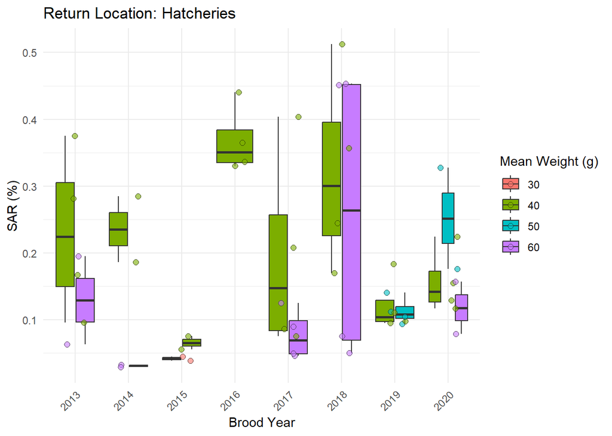

Figure 3: Smolt-adult return calcualted from the raw release and return data across brood years and mean weight release groups.

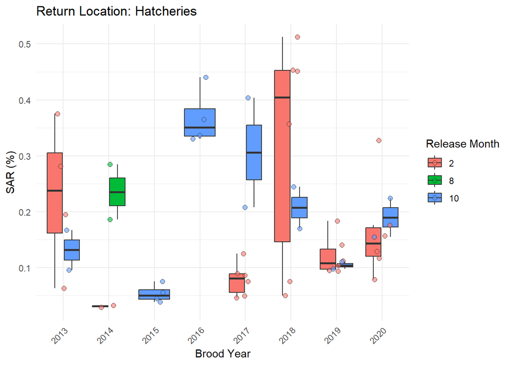

Figure 4: Smolt-adult return calcualted from the raw release and return data across brood years and release month.

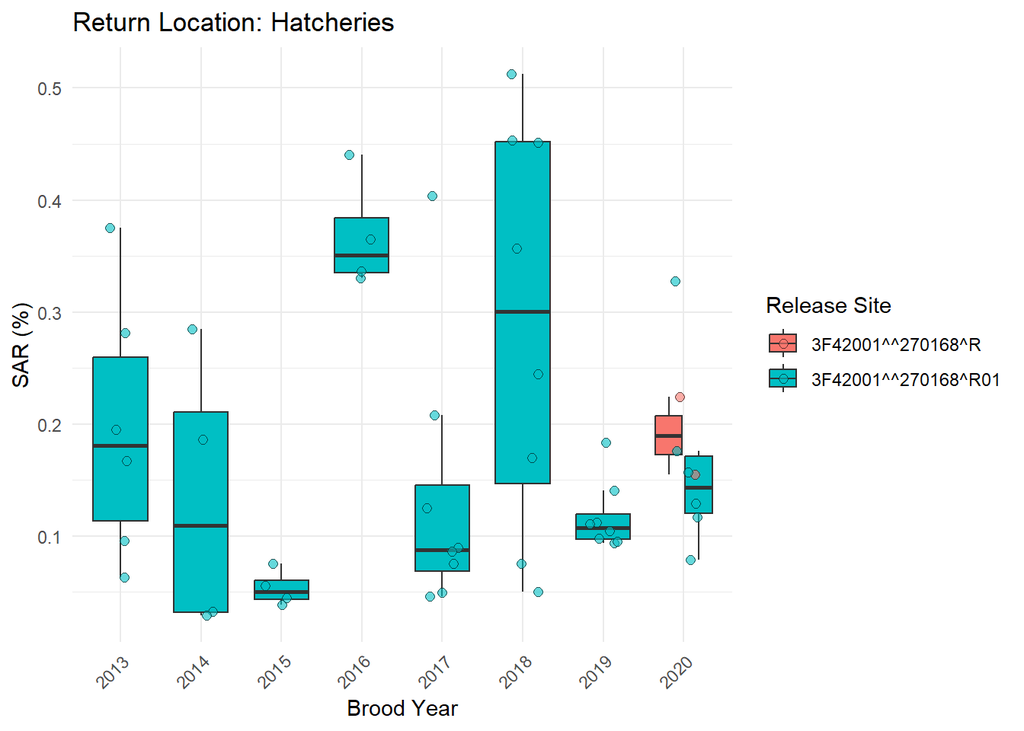

Figure 5: Smolt-adult return calcualted from the raw release and return data across brood years and release sites.

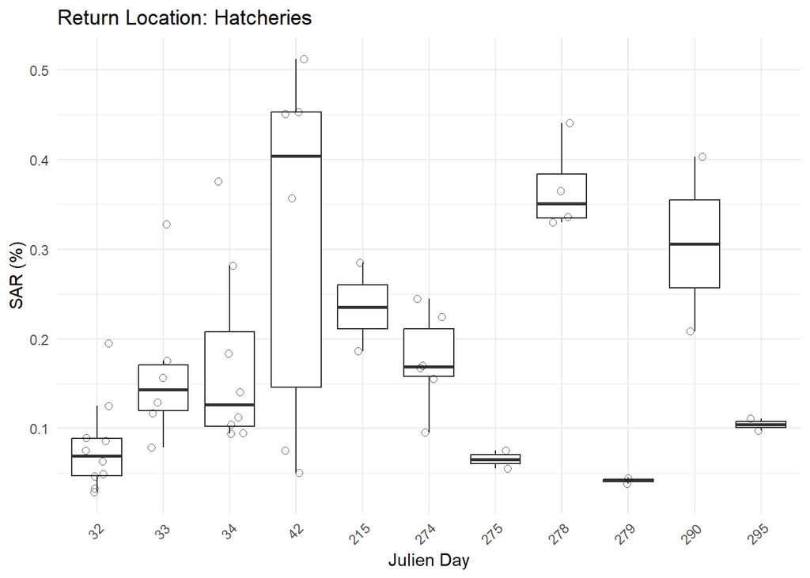

Figure 6: Smolt-adult return calcualted from the raw release and return data across brood years and julian days.

```r
### hatchery sar
# sar by brood year & mean wt
ggplot(data=filter(sar_df_fates, fate == "hatchery" & recovery_location_code %in% hatcheries),aes(x=as.factor(brood_year),y=sar*100, fill=as.factor(avg_weight)))+
    geom_boxplot(outlier.shape = NA)+
    geom_jitter(pch=21,size=2,width = 0.2, alpha=0.6)+
    # facet_wrap(.~run, ncol=1)+
    labs(x = "Brood Year", y = "SAR (%)", fill = "Mean Weight (g)", title = paste0("Return Location: Hatcheries"))+
    theme(axis.text.x = element_text(angle = 45, hjust = 1))

# sar by brood year & release month
ggplot(data=filter(sar_df_fates, fate == "hatchery" & recovery_location_code %in% hatcheries),aes(x=as.factor(brood_year),y=sar*100, fill=as.factor(first_release_date_month)))+
    geom_boxplot(outlier.shape = NA)+
    geom_jitter(pch=21,size=2,width = 0.2, alpha=0.6)+
    # facet_wrap(.~run, ncol=1)+
    labs(x = "Brood Year", y = "SAR (%)", fill = "Release Month", title = paste0("Return Location: Hatcheries"))+
    # scale_x_continuous(limits=c(min(sar_df$brood_year),max(sar_df$brood_year)), breaks=seq(min(sar_df$brood_year),max(sar_df$brood_year),1))+
    theme(axis.text.x = element_text(angle = 45, hjust = 1)) # Angle x-axis labels for readability

# sar by release location
ggplot(data=filter(sar_df_fates, fate == "hatchery" & recovery_location_code %in% hatcheries),aes(x=as.factor(brood_year),y=sar*100, fill=as.factor(release_location_code)))+
    geom_boxplot(outlier.shape = NA)+
    geom_jitter(pch=21,size=2,width = 0.2, alpha=0.6)+
    # facet_wrap(.~run, ncol=1)+
    labs(x = "Brood Year", y = "SAR (%)", fill = "Release Site", title = paste0("Return Location: Hatcheries"))+
    theme(axis.text.x = element_text(angle = 45, hjust = 1)) # Angle x-axis labels for readability

# sar by release timing (jday)
ggplot(data=filter(sar_df_fates, fate == "hatchery" & recovery_location_code %in% hatcheries),aes(x=as.factor(jday),y=sar*100))+
    # geom_hdr() +
    geom_boxplot(outlier.shape = NA)+
    geom_jitter(pch=21,size=2,width = 0.2, alpha=0.6)+
    # geom_density_2d_filled(alpha = 0.8) +
    labs(x = "Julien Day", y = "SAR (%)", fill = "Release Site", title = paste0("Return Location: Hatcheries"))+
    # facet_wrap(.~run, ncol=1)+
    theme(axis.text.x = element_text(angle = 45, hjust = 1))+ # Angle x-axis labels for readability
    theme(legend.position = "none")
```

Below we report the SAR values shown in the figures above so the reader has access to the individual data points. Note that the figures report SAR in percentages, while the table values are raw values.

```r
sar_hatch_tab <-sar_df_fates[,c("species","brood_year","release_location_code","recovery_location_code","first_release_date_month",
                                "jday","avg_weight","event_released","sar","fate")]%>%
  filter(., fate == "hatchery" & recovery_location_code %in% hatcheries) %>%
  rename("month" = first_release_date_month) %>%
  arrange(brood_year, month, avg_weight) #%>%

sar_hatch_tab %>%
  select(-c(brood_year,fate)) %>%
  kbl(row.names = NA) %>%
  kable_classic(position="left",full_width = F, html_font = "Cambria") %>%
  kable_styling(bootstrap_options = c("condensed")) %>%
  scroll_box(height = "400px") %>%
  pack_rows(index = table(sar_hatch_tab$brood_year))
```

Table 4: Smolt-adult return calculated across brood years, mean weight-at-release, and time at release.

| species | release_location_code | recovery_location_code | month | jday | avg_weight | event_released | sar |
| --- | --- | --- | --- | --- | --- | --- | --- |
| **2013** |  |  |  |  |  |  |  |
| 1 | 3F42001^^270168^R01 | 3F42001^^270168^H | 2 | 34 | 40 | 47259 | 0.0028153 |
| 1 | 3F42001^^270168^R01 | 3F42001^^270168^H | 2 | 34 | 40 | 47136 | 0.0037551 |
| 1 | 3F42001^^270168^R01 | 3F42001^^270168^H | 2 | 32 | 60 | 25220 | 0.0006344 |
| 1 | 3F42001^^270168^R01 | 3F42001^^270168^H | 2 | 32 | 60 | 25166 | 0.0019479 |
| 1 | 3F42001^^270168^R01 | 3F42001^^270168^H | 10 | 274 | 40 | 51109 | 0.0009587 |
| 1 | 3F42001^^270168^R01 | 3F42001^^270168^H | 10 | 274 | 40 | 50777 | 0.0016742 |
| **2014** |  |  |  |  |  |  |  |
| 1 | 3F42001^^270168^R01 | 3F42001^^270168^H | 2 | 32 | 60 | 58044 | 0.0003284 |
| 1 | 3F42001^^270168^R01 | 3F42001^^270168^H | 2 | 32 | 60 | 58276 | 0.0002934 |
| 1 | 3F42001^^270168^R01 | 3F42001^^270168^H | 8 | 215 | 40 | 73182 | 0.0018621 |
| 1 | 3F42001^^270168^R01 | 3F42001^^270168^H | 8 | 215 | 40 | 72782 | 0.0028481 |
| **2015** |  |  |  |  |  |  |  |
| 1 | 3F42001^^270168^R01 | 3F42001^^270168^H | 10 | 279 | 30 | 46852 | 0.0003865 |
| 1 | 3F42001^^270168^R01 | 3F42001^^270168^H | 10 | 279 | 30 | 47223 | 0.0004489 |
| 1 | 3F42001^^270168^R01 | 3F42001^^270168^H | 10 | 275 | 40 | 61567 | 0.0005560 |
| 1 | 3F42001^^270168^R01 | 3F42001^^270168^H | 10 | 275 | 40 | 61322 | 0.0007557 |
| **2016** |  |  |  |  |  |  |  |
| 1 | 3F42001^^270168^R01 | 3F42001^^270168^H | 10 | 278 | 40 | 47929 | 0.0033018 |
| 1 | 3F42001^^270168^R01 | 3F42001^^270168^H | 10 | 278 | 40 | 47929 | 0.0033635 |
| 1 | 3F42001^^270168^R01 | 3F42001^^270168^H | 10 | 278 | 40 | 99317 | 0.0036500 |
| 1 | 3F42001^^270168^R01 | 3F42001^^270168^H | 10 | 278 | 40 | 99317 | 0.0044069 |
| **2017** |  |  |  |  |  |  |  |
| 1 | 3F42001^^270168^R01 | 3F42001^^270168^H | 2 | 32 | 40 | 37336 | 0.0008619 |
| 1 | 3F42001^^270168^R01 | 3F42001^^270168^H | 2 | 32 | 40 | 37261 | 0.0007547 |
| 1 | 3F42001^^270168^R01 | 3F42001^^270168^H | 2 | 32 | 60 | 36724 | 0.0004651 |
| 1 | 3F42001^^270168^R01 | 3F42001^^270168^H | 2 | 32 | 60 | 36566 | 0.0004944 |
| 1 | 3F42001^^270168^R01 | 3F42001^^270168^H | 2 | 32 | 60 | 37807 | 0.0012495 |
| 1 | 3F42001^^270168^R01 | 3F42001^^270168^H | 2 | 32 | 60 | 38061 | 0.0008983 |
| 1 | 3F42001^^270168^R01 | 3F42001^^270168^H | 10 | 290 | 40 | 37733 | 0.0020823 |
| 1 | 3F42001^^270168^R01 | 3F42001^^270168^H | 10 | 290 | 40 | 37909 | 0.0040355 |
| **2018** |  |  |  |  |  |  |  |
| 1 | 3F42001^^270168^R01 | 3F42001^^270168^H | 2 | 42 | 40 | 35655 | 0.0035706 |
| 1 | 3F42001^^270168^R01 | 3F42001^^270168^H | 2 | 42 | 40 | 35585 | 0.0051232 |
| 1 | 3F42001^^270168^R01 | 3F42001^^270168^H | 2 | 42 | 60 | 34049 | 0.0045320 |
| 1 | 3F42001^^270168^R01 | 3F42001^^270168^H | 2 | 42 | 60 | 35688 | 0.0005049 |
| 1 | 3F42001^^270168^R01 | 3F42001^^270168^H | 2 | 42 | 60 | 33981 | 0.0045119 |
| 1 | 3F42001^^270168^R01 | 3F42001^^270168^H | 2 | 42 | 60 | 35835 | 0.0007562 |
| 1 | 3F42001^^270168^R01 | 3F42001^^270168^H | 10 | 274 | 40 | 32997 | 0.0017017 |
| 1 | 3F42001^^270168^R01 | 3F42001^^270168^H | 10 | 274 | 40 | 33193 | 0.0024445 |
| **2019** |  |  |  |  |  |  |  |
| 1 | 3F42001^^270168^R01 | 3F42001^^270168^H | 2 | 34 | 40 | 34886 | 0.0009500 |
| 1 | 3F42001^^270168^R01 | 3F42001^^270168^H | 2 | 34 | 40 | 35077 | 0.0018360 |
| 1 | 3F42001^^270168^R01 | 3F42001^^270168^H | 2 | 34 | 50 | 35306 | 0.0009404 |
| 1 | 3F42001^^270168^R01 | 3F42001^^270168^H | 2 | 34 | 50 | 33995 | 0.0011231 |
| 1 | 3F42001^^270168^R01 | 3F42001^^270168^H | 2 | 34 | 50 | 35621 | 0.0010435 |
| 1 | 3F42001^^270168^R01 | 3F42001^^270168^H | 2 | 34 | 50 | 34339 | 0.0014060 |
| 1 | 3F42001^^270168^R01 | 3F42001^^270168^H | 10 | 295 | 40 | 37087 | 0.0009772 |
| 1 | 3F42001^^270168^R01 | 3F42001^^270168^H | 10 | 295 | 40 | 37210 | 0.0011083 |
| **2020** |  |  |  |  |  |  |  |
| 1 | 3F42001^^270168^R01 | 3F42001^^270168^H | 2 | 33 | 40 | 36749 | 0.0011701 |
| 1 | 3F42001^^270168^R01 | 3F42001^^270168^H | 2 | 33 | 40 | 37096 | 0.0012939 |
| 1 | 3F42001^^270168^R01 | 3F42001^^270168^H | 2 | 33 | 50 | 36983 | 0.0017578 |
| 1 | 3F42001^^270168^R01 | 3F42001^^270168^H | 2 | 33 | 50 | 36906 | 0.0032786 |
| 1 | 3F42001^^270168^R01 | 3F42001^^270168^H | 2 | 33 | 60 | 31832 | 0.0015707 |
| 1 | 3F42001^^270168^R01 | 3F42001^^270168^H | 2 | 33 | 60 | 31724 | 0.0007880 |
| 1 | 3F42001^^270168^R | 3F42001^^270168^H | 10 | 274 | 40 | 38327 | 0.0022441 |
| 1 | 3F42001^^270168^R | 3F42001^^270168^H | 10 | 274 | 40 | 37378 | 0.0015520 |

**Spawning Ground SAR**

Paired release-recovery data are filtered for ‘spawngr’ fates in this section, and used to calculate spawning ground SARs. We first report the recovery_location_codes present in the filtered data and the estimated recoveries (number_cwt_estimated) for each recovery location. There may be strays present, because more work is needed to identify spawning grounds associated with stocks of interest.

Table 5: Recovery locations associated with a ‘spawngr’ fate in the filtered data, and the number of estimated recoveries (number_cwt_estimated) reported for each recovery location.

| recovery_location_code | name | latitude | longitude | psc_region | number_cwt_estimated |
| --- | --- | --- | --- | --- | --- |
| 3F42001^^270168^R | LEWIS R 27.0168 | 45.8504 | -122.7824 | LOCR | 417.63 |

Hatchery release treatments affecting sizes at release or timing of release are shown by aggregating the filtered release-return data by the treatment variables size-at-release, release month, release site, and julian day of release,

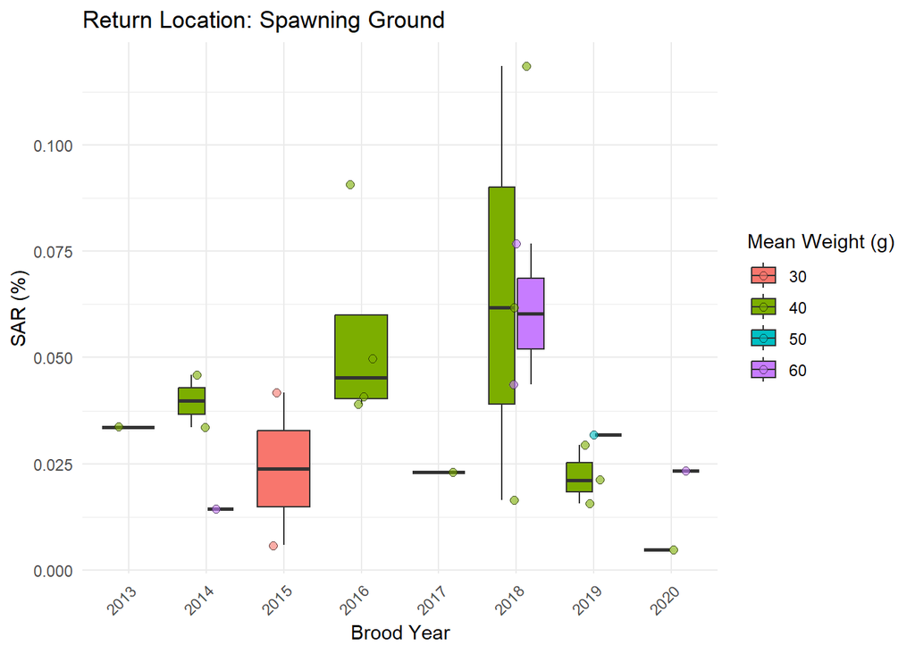

Figure 7: Smolt-adult return calcualted from the raw release and return data across brood years and mean weight release groups.

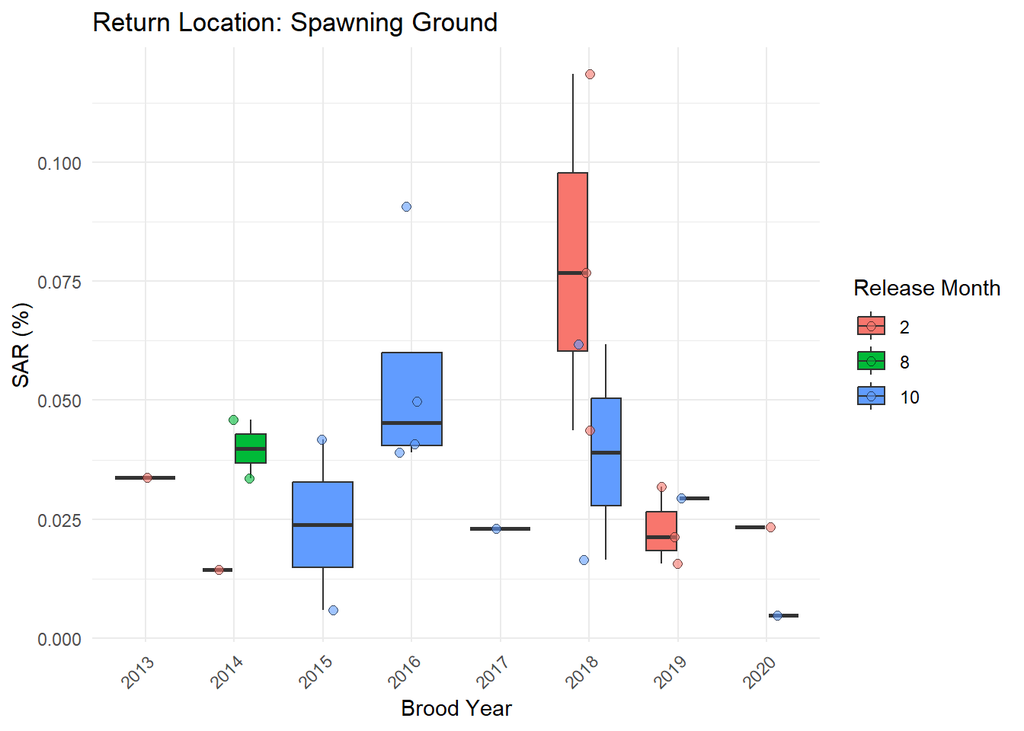

Figure 8: Smolt-adult return calcualted from the raw release and return data across brood years and release month.

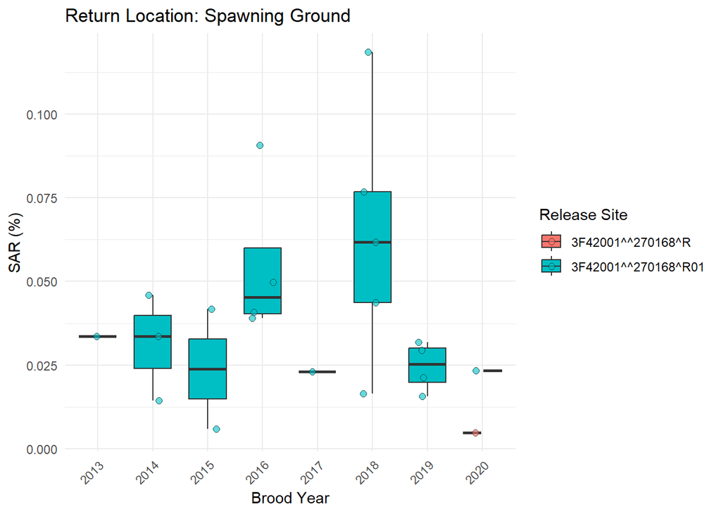

Figure 9: Smolt-adult return calcualted from the raw release and return data across brood years and release sites.

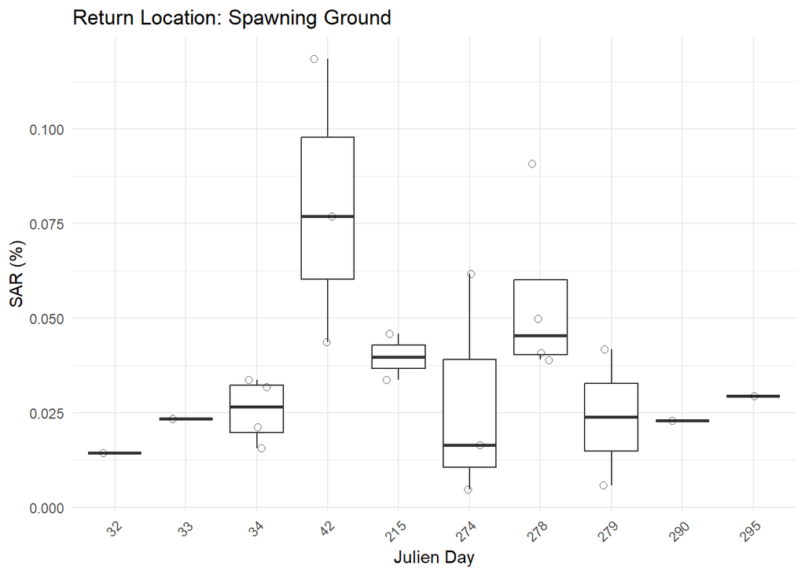

Figure 10: Smolt-adult return calcualted from the raw release and return data across brood years and julian days.

```r
### spawngr sar
# sar by brood year & mean wt
ggplot(data=filter(sar_df_fates, fate == "spawngr" & recovery_location_code %in% spawngr_recover),aes(x=as.factor(brood_year),y=sar*100, fill=as.factor(avg_weight)))+
    geom_boxplot(outlier.shape = NA)+
    geom_jitter(pch=21,size=2,width = 0.2, alpha=0.6)+
    # facet_wrap(.~run, ncol=1)+
    labs(x = "Brood Year", y = "SAR (%)", fill = "Mean Weight (g)", title = paste0("Return Location: Spawning Ground"))+
    theme(axis.text.x = element_text(angle = 45, hjust = 1))

# sar by brood year & release month
ggplot(data=filter(sar_df_fates, fate == "spawngr" & recovery_location_code %in% spawngr_recover),aes(x=as.factor(brood_year),y=sar*100, fill=as.factor(first_release_date_month)))+
    geom_boxplot(outlier.shape = NA)+
    geom_jitter(pch=21,size=2,width = 0.2, alpha=0.6)+
    # facet_wrap(.~run, ncol=1)+
    labs(x = "Brood Year", y = "SAR (%)", fill = "Release Month", title = paste0("Return Location: Spawning Ground"))+
    # scale_x_continuous(limits=c(min(sar_df$brood_year),max(sar_df$brood_year)), breaks=seq(min(sar_df$brood_year),max(sar_df$brood_year),1))+
    theme(axis.text.x = element_text(angle = 45, hjust = 1)) # Angle x-axis labels for readability

# sar by release location
ggplot(data=filter(sar_df_fates, fate == "spawngr" & recovery_location_code %in% spawngr_recover),aes(x=as.factor(brood_year),y=sar*100, fill=as.factor(release_location_code)))+
    geom_boxplot(outlier.shape = NA)+
    geom_jitter(pch=21,size=2,width = 0.2, alpha=0.6)+
    # facet_wrap(.~run, ncol=1)+
    labs(x = "Brood Year", y = "SAR (%)", fill = "Release Site", title = paste0("Return Location: Spawning Ground"))+
    theme(axis.text.x = element_text(angle = 45, hjust = 1)) # Angle x-axis labels for readability

# sar by release timing (jday)
ggplot(data=filter(sar_df_fates, fate == "spawngr" & recovery_location_code %in% spawngr_recover),aes(x=as.factor(jday),y=sar*100))+
    # geom_hdr() +
    geom_boxplot(outlier.shape = NA)+
    geom_jitter(pch=21,size=2,width = 0.2, alpha=0.6)+
    # geom_density_2d_filled(alpha = 0.8) +
    labs(x = "Julien Day", y = "SAR (%)", fill = "Release Site", title = paste0("Return Location: Spawning Ground"))+
    # facet_wrap(.~run, ncol=1)+
    theme(axis.text.x = element_text(angle = 45, hjust = 1))+ # Angle x-axis labels for readability
    theme(legend.position = "none")
```

Below we report the SAR values shown in the figures above so the reader has access to the individual data points. Note that the figures report SAR in percentages, while the table values are raw values.

```r
sar_spawngr_tab <-sar_df_fates[,c("species","brood_year","release_location_code","recovery_location_code",
                                  "first_release_date_month","jday","avg_weight","event_released","fate","sar")]%>%
  filter(., fate == "spawngr") %>%
  rename("month" = first_release_date_month) %>%
  arrange(brood_year, month, avg_weight) #%>%

sar_spawngr_tab %>%
  select(-c(brood_year,fate)) %>%
  kbl(row.names = NA) %>%
  kable_classic(position="left",full_width = F, html_font = "Cambria") %>%
  kable_styling(bootstrap_options = c("condensed")) %>%
  scroll_box(height = "400px") %>%
  pack_rows(index = table(sar_spawngr_tab$brood_year))
```

Table 6: Smolt-adult return calculated across brood years, mean weight-at-release, and time at release.

| species | release_location_code | recovery_location_code | month | jday | avg_weight | event_released | sar |
| --- | --- | --- | --- | --- | --- | --- | --- |
| **2013** |  |  |  |  |  |  |  |
| 1 | 3F42001^^270168^R01 | 3F42001^^270168^R | 2 | 34 | 40 | 47259 | 0.0003367 |
| **2014** |  |  |  |  |  |  |  |
| 1 | 3F42001^^270168^R01 | 3F42001^^270168^R | 2 | 32 | 60 | 58276 | 0.0001433 |
| 1 | 3F42001^^270168^R01 | 3F42001^^270168^R | 8 | 215 | 40 | 73182 | 0.0003364 |
| 1 | 3F42001^^270168^R01 | 3F42001^^270168^R | 8 | 215 | 40 | 72782 | 0.0004589 |
| **2015** |  |  |  |  |  |  |  |
| 1 | 3F42001^^270168^R01 | 3F42001^^270168^R | 10 | 279 | 30 | 46852 | 0.0004179 |
| 1 | 3F42001^^270168^R01 | 3F42001^^270168^R | 10 | 279 | 30 | 47223 | 0.0000582 |
| **2016** |  |  |  |  |  |  |  |
| 1 | 3F42001^^270168^R01 | 3F42001^^270168^R | 10 | 278 | 40 | 47929 | 0.0009076 |
| 1 | 3F42001^^270168^R01 | 3F42001^^270168^R | 10 | 278 | 40 | 47929 | 0.0004085 |
| 1 | 3F42001^^270168^R01 | 3F42001^^270168^R | 10 | 278 | 40 | 99317 | 0.0003900 |
| 1 | 3F42001^^270168^R01 | 3F42001^^270168^R | 10 | 278 | 40 | 99317 | 0.0004980 |
| **2017** |  |  |  |  |  |  |  |
| 1 | 3F42001^^270168^R01 | 3F42001^^270168^R | 10 | 290 | 40 | 37733 | 0.0002300 |
| **2018** |  |  |  |  |  |  |  |
| 1 | 3F42001^^270168^R01 | 3F42001^^270168^R | 2 | 42 | 40 | 35585 | 0.0011853 |
| 1 | 3F42001^^270168^R01 | 3F42001^^270168^R | 2 | 42 | 60 | 34049 | 0.0004373 |
| 1 | 3F42001^^270168^R01 | 3F42001^^270168^R | 2 | 42 | 60 | 33981 | 0.0007687 |
| 1 | 3F42001^^270168^R01 | 3F42001^^270168^R | 10 | 274 | 40 | 32997 | 0.0006170 |
| 1 | 3F42001^^270168^R01 | 3F42001^^270168^R | 10 | 274 | 40 | 33193 | 0.0001648 |
| **2019** |  |  |  |  |  |  |  |
| 1 | 3F42001^^270168^R01 | 3F42001^^270168^R | 2 | 34 | 40 | 34886 | 0.0001568 |
| 1 | 3F42001^^270168^R01 | 3F42001^^270168^R | 2 | 34 | 40 | 35077 | 0.0002118 |
| 1 | 3F42001^^270168^R01 | 3F42001^^270168^R | 2 | 34 | 50 | 34339 | 0.0003186 |
| 1 | 3F42001^^270168^R01 | 3F42001^^270168^R | 10 | 295 | 40 | 37210 | 0.0002940 |
| **2020** |  |  |  |  |  |  |  |
| 1 | 3F42001^^270168^R01 | 3F42001^^270168^R | 2 | 33 | 60 | 31832 | 0.0002334 |
| 1 | 3F42001^^270168^R | 3F42001^^270168^R | 10 | 274 | 40 | 38327 | 0.0000480 |

**Fishery SAR**

Paired release-recovery data are filtered for ‘fishery’ fates in this section, and used to calculate fishery SARs. We first report the recovery_location_codes present in the filtered data and the estimated recoveries (number_cwt_estimated) for each recovery location.

```r
### fishery sar
# rRMIS::fishery_lut
# terminal vs. columbia vs. ocean
# rec vs. commmercial
# size-at-release groups & their contribution to fishery types/locations


### Table showing release and return locations after data filtering
fishery_recover <-unique(filter(sar_df_fates, fate=="fishery")$recovery_location_code)
fishery_recover_name <-list()

for(i in 1:length(fishery_recover)){
  fishery_recover_name[[i]] <-filter(loc_all, location_code == fishery_recover[i])[1,c("location_code","name","latitude","longitude","psc_region")]
  }

fishery_recover_sum <-aggregate(number_cwt_estimated~recovery_location_code, data=filter(sar_df_fates, fate=="fishery"),FUN=sum)
fishery_recover_df <-fishery_recover_name %>% map_df(., ~as.data.frame(.)) %>%
                                          rename("recovery_location_code" = location_code) %>%
                                          left_join(., fishery_recover_sum, by="recovery_location_code") %>%
                                          arrange(desc(number_cwt_estimated))

fishery_recover_df %>%
  # filter(., location_code %in% hatch_recover) %>%
  # rename("month" = first_release_date_month) %>%
  # arrange(brood_year, month,avg_weight) %>%
  # select(-brood_year)%>%
  kbl(row.names = NA)%>%
  kable_classic(position="left",full_width = F, html_font = "Cambria")%>%
  scroll_box(height = "400px") %>%
  kable_styling(bootstrap_options = c("condensed")) #%>% pack_rows(index = table(sar_df$brood_year))
```

Table 7: Recovery locations associated with a ‘fishery’ fate in the filtered data, and the number of estimated recoveries (number_cwt_estimated) reported for each recovery location.

| recovery_location_code | name | latitude | longitude | psc_region | number_cwt_estimated |
| --- | --- | --- | --- | --- | --- |
| 3F42001^^270168^R01 | LEWIS R -NF 27.0168 | 45.8504 | -122.7824 | LOCR | 130.20 |
| 2MN06P101^^^^^^^000 | NTR P101-000 | NA | NA | NA | 43.08 |
| 5F33207^^R7^^^^^13 | YOUNGS BAY NET ZONE 7 | 46.1917 | -123.8833 | LOCR | 42.20 |
| 3F42001^^270002^R | KALAMA R 27.0002 | 46.0338 | -122.8746 | LOCR | 39.24 |
| 5F33271^^R71^^^^13 | TONGUE POINT ZONE 71 | NA | NA | LOCR | 28.48 |
| 1M2PW212 | AK M 2 PW 212 | NA | NA | CEAK | 19.54 |
| 5F33203^^R209^^^12 | COL R OR SPORT SEC 9 | NA | NA | LOCR | 18.95 |
| 2MN06P142^^^^^^^000 | NTR P142-000 | NA | NA | NA | 17.41 |
| 5F33307^^R4^^^^^14 | WILLAMETTE R LWR BTS | NA | NA | LOCR | 16.42 |
| 1M1NW154 | AK M 1 NW 154 | NA | NA | SEAK | 14.87 |
| 3M32202 | MARINE AREA 2 | NA | NA | GRAY | 14.17 |
| 5F33203^^R110^^^12 | COL R WA SPORT SEC 10 | NA | NA | LOCR | 12.95 |
| 1M1NW113^41 | AK M 1 NW 113-41 | NA | NA | SEAK | 11.95 |
| 5F33203^^R106^^^12 | COL R WA SEC 6 | NA | NA | LOCR | 10.50 |
| 1M1NW | AK M 1 NW | NA | NA | SEAK | 8.54 |
| 3M32303 | MARINE AREA 3 | NA | NA | NWC | 8.45 |
| 5F33203^^R204^^^12 | COL R OR SPORT SEC 4 | NA | NA | LOCR | 8.34 |
| 2MSSVP123 | SWVISPT P123 | NA | NA | NA | 7.92 |
| 5F33203^^R109^^^12 | COL R WA SPORT SEC 9 | NA | NA | LOCR | 7.64 |
| 1M1SW152 | AK M 1 SW 152 | NA | NA | SEAK | 7.04 |
| 3F42001^^260002^R | COWLITZ R 26.0002 | 46.0956 | -122.9155 | LOCR | 6.35 |
| 5F33203^^R205^^^12 | COL R OR SPORT SEC 5 | NA | NA | LOCR | 5.96 |
| 5F33203^^R104^^^12 | COL R WA SEC 4 | NA | NA | LOCR | 5.69 |
| 1M1NW113^91 | AK M 1 NW 113-91 | NA | NA | SEAK | 4.96 |
| 2MS01P127^^^^^^^000 | NWTR P127-000 | NA | NA | NA | 4.84 |
| 1M1SW104^4007^^MS | AK M 1 SW 104-4007 MS | NA | NA | SEAK | 4.76 |
| 6MO^^^^^^PAPR | PT.ARENA-PT.REYES | NA | NA | CAGN | 4.62 |
| 2MSNGP014SANG^IS^03 | NSGSPTSANG IS(14-3) | 49.4261 | -124.1992 | NA | 4.31 |
| 2MS02M111^^^^^^^000 | SWTR M111-000 | NA | NA | NA | 4.20 |
| 2MN06P001^^^^^^^000 | NTR P001-000 | NA | NA | NA | 4.18 |
| 5F33203^^R103^^^12 | COL R WA SPORT SEC 3 | NA | NA | LOCR | 4.10 |
| 1M1NW113^61 | AK M 1 NW 113-61 | NA | NA | SEAK | 4.08 |
| 1M1NW113^31 | AK M 1 NW 113-31 | NA | NA | SEAK | 3.95 |
| 1M1NW157 | AK M 1 NW 157 | NA | NA | SEAK | 3.95 |
| 5F33203^^R203^^^12 | COL R OR SPORT SEC 3 | NA | NA | LOCR | 3.67 |
| 2MS5SP024^^^^^^^000 | 5NWCVIS P024-000 | NA | NA | NA | 3.61 |
| 5F33274^^R74^^^^13 | BLIND SLOUGH ZONE 74 | NA | NA | LOCR | 3.38 |
| 5F33307^^R3^^^^^14 | WILLAMETTE R (MIDRIV | NA | NA | LOCR | 3.31 |
| 3M32404 | MARINE AREA 4 | NA | NA | NWC | 3.31 |
| 1M1NE109^61 | AK M 1 NE 109-61 | NA | NA | SEAK | 3.27 |
| 1M1NE109^10 | AK M 1 NE 109-10 | NA | NA | SEAK | 3.17 |
| 7M3^^^^N^^^^W^^^630 | HIGH SEAS 3 N W US 630 | NA | NA | NA | 3.00 |
| 5F33220^^R20^^^^15 | NEW TEST ZONE 2 | NA | NA | LOCR | 3.00 |
| 1M1SWSASO | AK M 1 SW SASO | NA | NA | SEAK | 2.79 |
| 1M1NW116^11 | AK M 1 NW 116-11 | NA | NA | SEAK | 2.63 |
| 1M1NW113^22 | AK M 1 NW 113-22 | NA | NA | SEAK | 2.40 |
| 2MS02P123^^^^^^^000 | SWTR P123-000 | NA | NA | NA | 2.40 |
| 2MS01M403^^^^^^^000 | NWTR M403-000 | NA | NA | NA | 2.22 |
| 3M42001^^A | 1A (BUOY10 - BRIDGE) | NA | NA | LOCR | 2.04 |
| 5F33283^^R83^^^^15 | COL R ZONE 83 CATHLAMET | NA | NA | LOCR | 2.00 |
| 7M3^^^^N^^^^W^^^610 | HIGH SEAS 3 N W US 610 | NA | NA | NA | 2.00 |
| 2MS02M23B^^^^^^^000 | SWTR M23B-000 | NA | NA | NA | 1.94 |
| 2MS02M401^^^^^^^000 | SWTR M401-000 | NA | NA | NA | 1.81 |
| 5F33209^^R3^^^^^13 | COL R ZONE 3 NET | NA | NA | LOCR | 1.64 |
| 7M3^^^^N^^^^W^^^620 | HIGH SEAS 3 N W US 620 | NA | NA | NA | 1.00 |
| 2MS5SP124^^^^^^^000 | 5NWCVIS P124-000 | NA | NA | NA | 1.00 |
| 1M1 | AK M 1 | NA | NA | SEAK | 0.00 |
| 1M4KD | AK M 4 KD | NA | NA | WEAK | 0.00 |
| 1M2LC241^^^18^^MB | AK M 2 LC 241- 18 MB | NA | NA | CEAK | 0.00 |

Hatcheries release treatments affecting sizes at release or timing of release are shown by aggregating the filtered release-return data by the treatment variables size-at-release, release month, release site, and julian day of release,

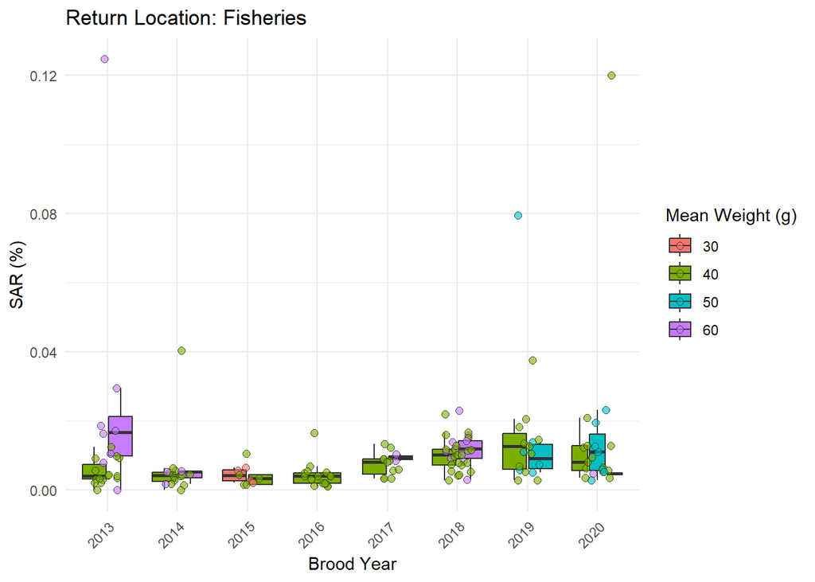

Figure 11: Smolt-adult return calcualted from the raw release and return data across brood years and mean weight release groups.

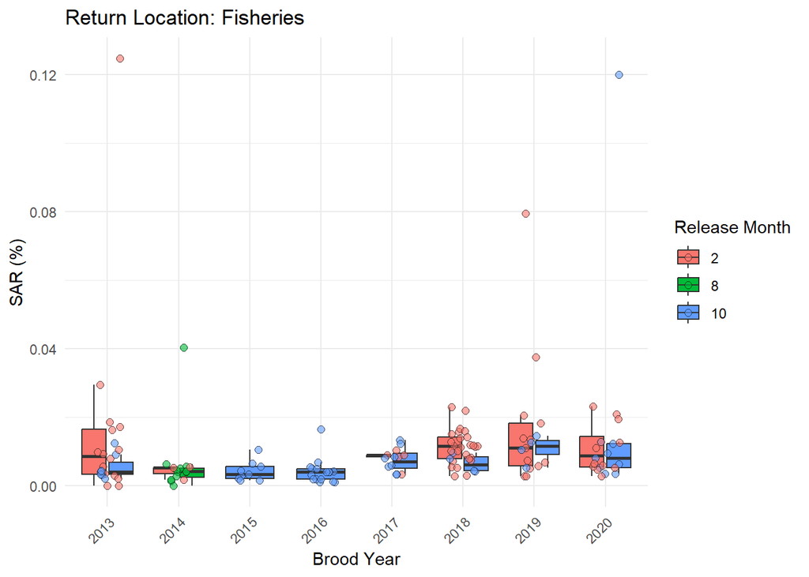

Figure 12: Smolt-adult return calcualted from the raw release and return data across brood years and release month.

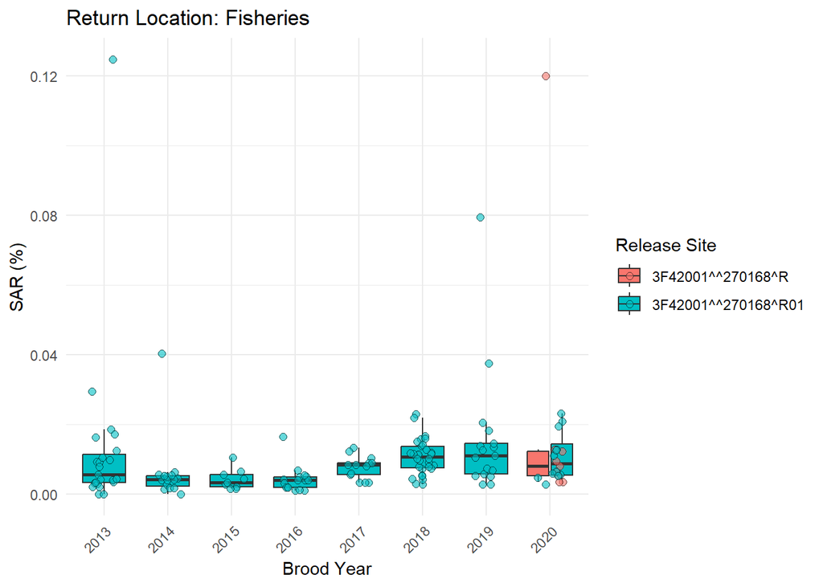

Figure 13: Smolt-adult return calcualted from the raw release and return data across brood years and release sites.

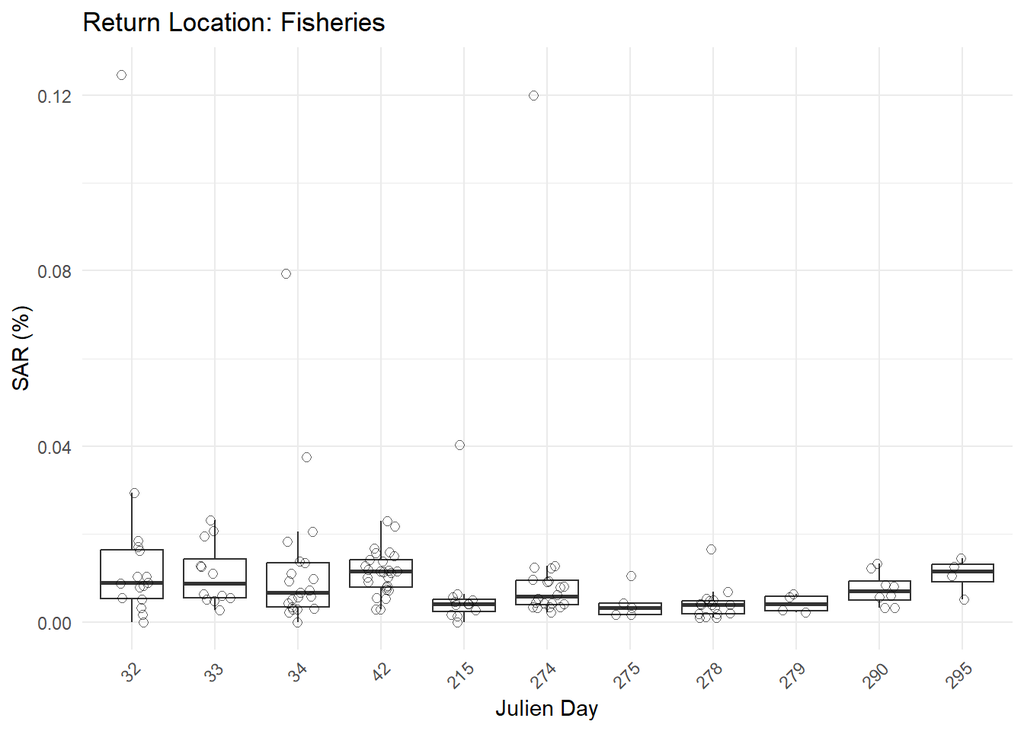

```r
### spawngr sar
# sar by brood year & mean wt
ggplot(data=filter(sar_df_fates, fate == "fishery" & recovery_location_code %in% fishery_recover),aes(x=as.factor(brood_year),y=sar*100, fill=as.factor(avg_weight)))+
    geom_boxplot(outlier.shape = NA)+
    geom_jitter(pch=21,size=2,width = 0.2, alpha=0.6)+
    # facet_wrap(.~run, ncol=1)+
    labs(x = "Brood Year", y = "SAR (%)", fill = "Mean Weight (g)", title = paste0("Return Location: Fisheries"))+
    theme(axis.text.x = element_text(angle = 45, hjust = 1))

# sar by brood year & release month
ggplot(data=filter(sar_df_fates, fate == "fishery" & recovery_location_code %in% fishery_recover),aes(x=as.factor(brood_year),y=sar*100, fill=as.factor(first_release_date_month)))+
    geom_boxplot(outlier.shape = NA)+
    geom_jitter(pch=21,size=2,width = 0.2, alpha=0.6)+
    # facet_wrap(.~run, ncol=1)+
    labs(x = "Brood Year", y = "SAR (%)", fill = "Release Month", title = paste0("Return Location: Fisheries"))+
    # scale_x_continuous(limits=c(min(sar_df$brood_year),max(sar_df$brood_year)), breaks=seq(min(sar_df$brood_year),max(sar_df$brood_year),1))+
    theme(axis.text.x = element_text(angle = 45, hjust = 1)) # Angle x-axis labels for readability

# sar by release location
ggplot(data=filter(sar_df_fates, fate == "fishery" & recovery_location_code %in% fishery_recover),aes(x=as.factor(brood_year),y=sar*100, fill=as.factor(release_location_code)))+
    # geom_boxplot(data=sar_df,aes(x=release_location_code,y=sar, group=release_location_code))+
    geom_boxplot(outlier.shape = NA)+
    geom_jitter(pch=21,size=2,width = 0.2, alpha=0.6)+
    # facet_wrap(.~run, ncol=1)+
    labs(x = "Brood Year", y = "SAR (%)", fill = "Release Site", title = paste0("Return Location: Fisheries"))+
    theme(axis.text.x = element_text(angle = 45, hjust = 1)) # Angle x-axis labels for readability

# sar by release timing (jday)
ggplot(data=filter(sar_df_fates, fate == "fishery" & recovery_location_code %in% fishery_recover),aes(x=as.factor(jday),y=sar*100))+
    # geom_hdr() +
    geom_boxplot(outlier.shape = NA)+
    geom_jitter(pch=21,size=2,width = 0.2, alpha=0.6)+
    # geom_density_2d_filled(alpha = 0.8) +
    labs(x = "Julien Day", y = "SAR (%)", fill = "Release Site", title = paste0("Return Location: Fisheries"))+
    # facet_wrap(.~run, ncol=1)+
    theme(axis.text.x = element_text(angle = 45, hjust = 1))+ # Angle x-axis labels for readability
    theme(legend.position = "none")
```

Below we report the SAR values shown in the figures above so the reader has access to the individual data points. Note that the figures report SAR in percentages, while the table values are raw values.

```r
sar_fishery_tab <-sar_df_fates[,c("species","brood_year","release_location_code","recovery_location_code",
                                  "first_release_date_month","jday","avg_weight","event_released","fate","sar")]%>%
  filter(., fate == "fishery") %>%
  rename("month" = first_release_date_month) %>%
  arrange(brood_year, month, avg_weight) #%>%

sar_fishery_tab %>%
  select(-c(brood_year,fate)) %>%
  # aggregate(number_cwt_estimated~recovery_location_code, data=.,FUN=sum)%>%
  kbl(row.names = NA) %>%
  kable_classic(position="left",full_width = F, html_font = "Cambria") %>%
  kable_styling(bootstrap_options = c("condensed")) %>%
  scroll_box(height = "400px") %>%
  pack_rows(index = table(sar_fishery_tab$brood_year))
```

Table 8: Smolt-adult return calculated across brood years, mean weight-at-release, and time at release.

| species | release_location_code | recovery_location_code | month | jday | avg_weight | event_released | sar |
| --- | --- | --- | --- | --- | --- | --- | --- |
| **2013** |  |  |  |  |  |  |  |
| 1 | 3F42001^^270168^R01 | 5F33207^^R7^^^^^13 | 2 | 34 | 40 | 47259 | 0.0000300 |
| 1 | 3F42001^^270168^R01 | 5F33271^^R71^^^^13 | 2 | 34 | 40 | 47259 | 0.0000561 |
| 1 | 3F42001^^270168^R01 | 7M3^^^^N^^^^W^^^630 | 2 | 34 | 40 | 47259 | 0.0000423 |
| 1 | 3F42001^^270168^R01 | 1M1 | 2 | 34 | 40 | 47259 | 0.0000000 |
| 1 | 3F42001^^270168^R01 | 3M32202 | 2 | 34 | 40 | 47259 | 0.0000925 |
| 1 | 3F42001^^270168^R01 | 5F33283^^R83^^^^15 | 2 | 34 | 40 | 47259 | 0.0000212 |
| 1 | 3F42001^^270168^R01 | 5F33207^^R7^^^^^13 | 2 | 34 | 40 | 47136 | 0.0000989 |
| 1 | 3F42001^^270168^R01 | 5F33271^^R71^^^^13 | 2 | 34 | 40 | 47136 | 0.0000344 |
| 1 | 3F42001^^270168^R01 | 5F33203^^R103^^^12 | 2 | 32 | 60 | 25220 | 0.0001626 |
| 1 | 3F42001^^270168^R01 | 5F33203^^R209^^^12 | 2 | 32 | 60 | 25220 | 0.0001856 |
| 1 | 3F42001^^270168^R01 | 1M4KD | 2 | 32 | 60 | 25220 | 0.0000000 |
| 1 | 3F42001^^270168^R01 | 3F42001^^270002^R | 2 | 32 | 60 | 25220 | 0.0012470 |
| 1 | 3F42001^^270168^R01 | 7M3^^^^N^^^^W^^^610 | 2 | 32 | 60 | 25220 | 0.0000793 |
| 1 | 3F42001^^270168^R01 | 2MSNGP014SANG^IS^03 | 2 | 32 | 60 | 25220 | 0.0001709 |
| 1 | 3F42001^^270168^R01 | 1M1NW116^11 | 2 | 32 | 60 | 25220 | 0.0001043 |
| 1 | 3F42001^^270168^R01 | 2MN06P101^^^^^^^000 | 2 | 32 | 60 | 25220 | 0.0002942 |
| 1 | 3F42001^^270168^R01 | 5F33209^^R3^^^^^13 | 10 | 274 | 40 | 51109 | 0.0000321 |
| 1 | 3F42001^^270168^R01 | 5F33271^^R71^^^^13 | 10 | 274 | 40 | 51109 | 0.0000211 |
| 1 | 3F42001^^270168^R01 | 5F33203^^R204^^^12 | 10 | 274 | 40 | 51109 | 0.0000916 |
| 1 | 3F42001^^270168^R01 | 3F42001^^260002^R | 10 | 274 | 40 | 51109 | 0.0001242 |
| 1 | 3F42001^^270168^R01 | 3M32202 | 10 | 274 | 40 | 51109 | 0.0000403 |
| 1 | 3F42001^^270168^R01 | 5F33207^^R7^^^^^13 | 10 | 274 | 40 | 50777 | 0.0000335 |
| 1 | 3F42001^^270168^R01 | 2MS01M403^^^^^^^000 | 10 | 274 | 40 | 50777 | 0.0000437 |
| **2014** |  |  |  |  |  |  |  |
| 1 | 3F42001^^270168^R01 | 1M1NE109^10 | 2 | 32 | 60 | 58044 | 0.0000546 |
| 1 | 3F42001^^270168^R01 | 2MN06P101^^^^^^^000 | 2 | 32 | 60 | 58044 | 0.0000517 |
| 1 | 3F42001^^270168^R01 | 5F33283^^R83^^^^15 | 2 | 32 | 60 | 58044 | 0.0000172 |
| 1 | 3F42001^^270168^R01 | 5F33207^^R7^^^^^13 | 8 | 215 | 40 | 73182 | 0.0000394 |
| 1 | 3F42001^^270168^R01 | 5F33203^^R110^^^12 | 8 | 215 | 40 | 73182 | 0.0000560 |

[output cut: 122 more lines]

## Fit SAR Models

```r
################################################################################
# [FIT_DAT] Prepare datasets for model fitting
### Join Release & Return Data for SAR
sar_df_fit <-sar_df_fates %>% select(-sar) %>%
                              aggregate(cbind(event_released, number_cwt_estimated) ~ species + brood_year +
                                                                                      release_location_code + hatchery_location_code +
                                                                                      first_release_date_month + jday + avg_weight +
                                                                                      release_stage_assigned + fate,
                                                                                      data=., FUN=sum)

sar_df_fit$sar <-sar_df_fit$number_cwt_estimated/sar_df_fit$event_released
sar_df_fit$tags_lost <-sar_df_fit$event_released - sar_df_fit$number_cwt_estimated
sar_df_fit$fate <-as.factor(sar_df_fit$fate)
# sar_df_fit$run <-as.factor(sar_df_fit$run)

write.csv(sar_df_fit, paste0(proj_drive,"/data/sar_df_fit_",params$system,"_",params$sp,"_",params$run,".csv"))

k_by <-length(unique(sar_df_fates$brood_year))
k_jday <-length(unique(sar_df_fates$jday))
k_wt <-length(unique(sar_df_fates$avg_weight))
# k_run <-length(unique(sar_df_fates$run))
k_fate <-length(unique(sar_df_fates$fate))


# (Default) m = 2 penalizes the second derivative (squared curvature), leading to a "visually smooth" fit
# m = 1 penalizes the first derivative (slope), which can result in a more "piecewise" appearance
mod <-mgcv::gam(cbind(round(number_cwt_estimated), round(tags_lost)) ~
              + fate
              + s(brood_year, bs="ps", m=1, k=k_by)
              # + s(run, bs="ts", m=2, k=k_run)
              # + s(fate, bs="ts", m=2, k=k_fate)
              # + s(jday, bs="cc", m=2, k=k_jday)
              + s(avg_weight, bs="ts", m=2, k=k_wt)
              + te(jday, brood_year, bs = c("cc", "ps")),
              family=quasibinomial(link="logit"), data=sar_df_fit, method="REML",
              na.action = "na.fail",
              select=T)

### fit alternate model without fate
# sar_df_fit2 <-sar_df %>%
#                 select(-c(sar)) %>%
#                 filter(.,fishery==50) %>%
#                 aggregate(cbind(event_released,number_cwt_estimated)~ species + brood_year + avg_weight + jday, data=., FUN=sum)
#
# sar_df_fit2$tags_lost <-sar_df_fit2$event_released - sar_df_fit2$number_cwt_estimated
#
# mod2 <-mgcv::gam(cbind(round(number_cwt_estimated), round(tags_lost)) ~
#               # + fate
#               + s(brood_year, bs="ps", m=1, k=k_by)
#               # + s(run, bs="ts", m=2, k=k_run)
#               # + s(fate, bs="ts", m=2, k=k_fate)
#               # + s(jday, bs="cc", m=2, k=k_jday)
#               + s(avg_weight, bs="ts", m=2, k=k_wt)
#               + te(jday, brood_year, bs = c("cc", "ps")),
#               family=quasibinomial(link="logit"), data=sar_df_fit2, method="REML",
#               na.action = "na.fail",
#               select=T)

# print(summary(mod))
flextable::as_flextable(mod)
```

[output not shown]

Signif. codes: 0 <= '***' < 0.001 < '**' < 0.01 < '*' < 0.05  
Adjusted R-squared: 0.901, Deviance explained 0.905  
-REML : -225.376, Scale est: 11.831, N: 56

```r
# print(mod)
# print(gam.check(mod))


# Make predictions without including "tag_code"
preds <-predict(mod, newdata = sar_df_fit, type = "response", se.fit = T) |>
        as_tibble() |>
        rename(prediction = fit, pred_se = se.fit) |>
        mutate(lci = qnorm(0.025, prediction, pred_se),
               uci = qnorm(0.975, prediction, pred_se))#,
               # across(lci, ~ case_when(. < 0 ~ 0, .default = .)))

# add predictions
sar_pred <-sar_df_fit |> bind_cols(preds)
```

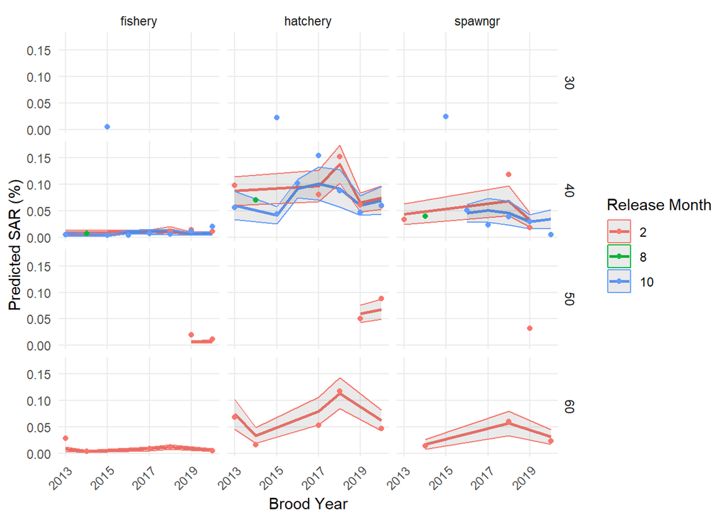

Figure 15: Predicted smolt-adult return generated from the model fit across fate, brood years, mean weight release groups, and release month.

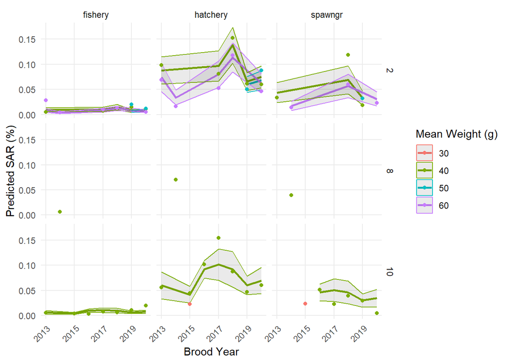

Figure 16: Predicted smolt-adult return generated from the model fit across fate, brood years, mean weight release groups, and release month.

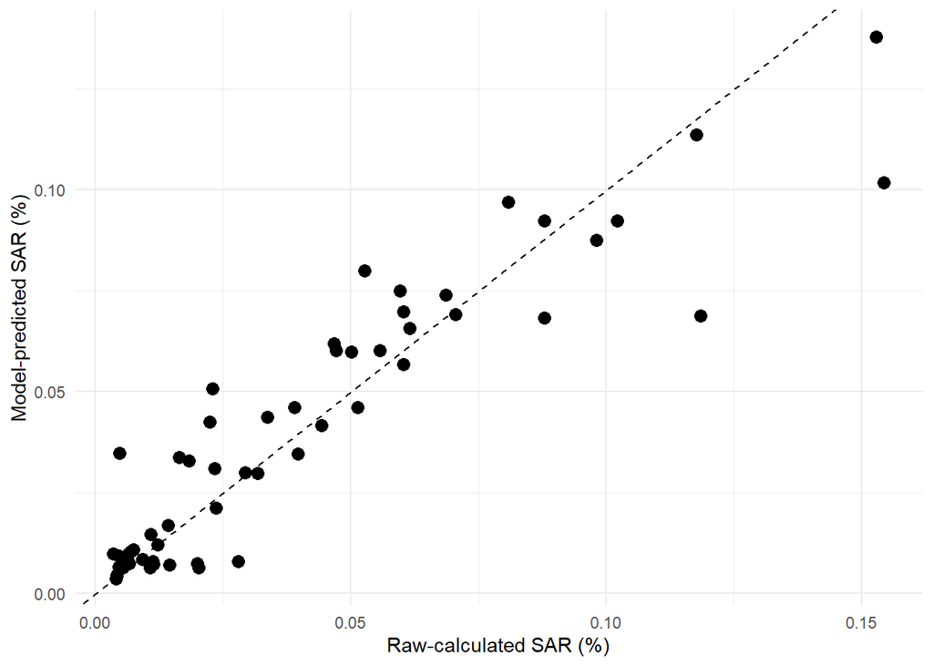

Figure 17: Raw-calculated vs. Model-predicted smolt-adult return generated from the model fit.

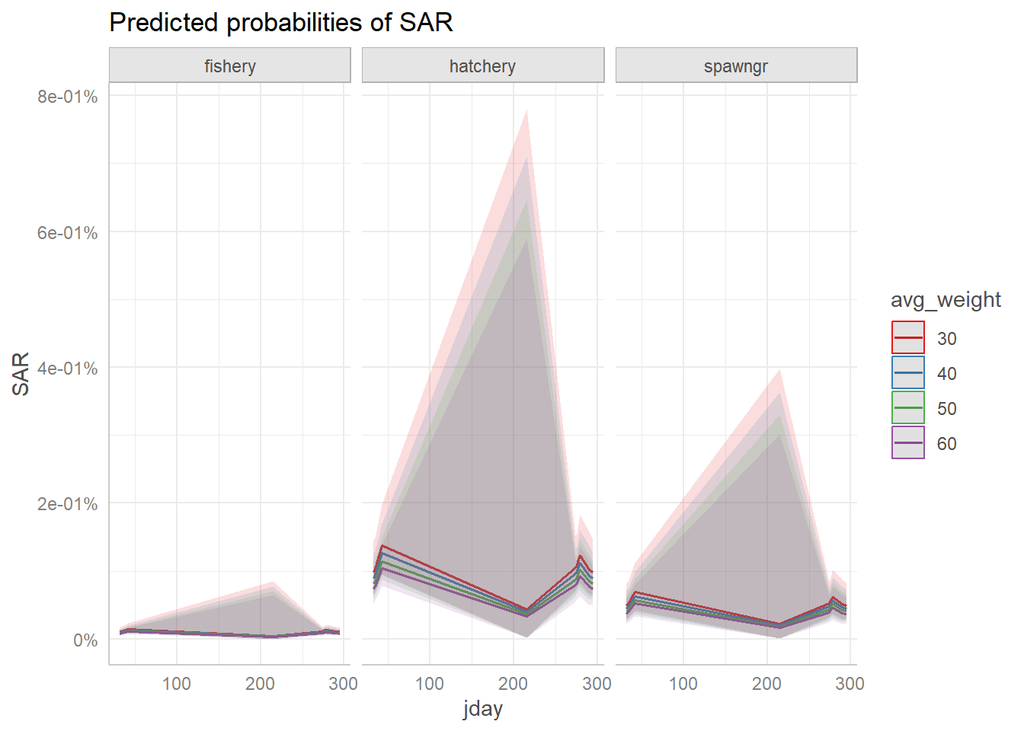

Figure 18: Marginal effects from the model fit showing how combined changes in mean weight at release and release timing (jday) affect smolt-adult-return across fates.

```r
#create some plots
ggplot(sar_pred, aes(x=brood_year,y=sar*100,group=first_release_date_month,color=as.factor(first_release_date_month))) +
  geom_line(aes(x = brood_year, y = prediction*100,group=first_release_date_month), linewidth=1) +
  geom_ribbon(aes(ymin = lci*100,ymax = uci*100,group=first_release_date_month,color = as.factor(first_release_date_month)),alpha = 0.1) +
  geom_point(aes(group=first_release_date_month)) +
  facet_grid(avg_weight~fate)+
  labs(x = "Brood Year", y = "Predicted SAR (%)", color="Release Month") +
  scale_x_continuous(breaks=seq(min(sar_pred$brood_year),max(sar_pred$brood_year),2))+
  # scale_y_log10(breaks = scales::breaks_pretty()) +
  # scale_y_continuous(trans = "log",
  #                    breaks = scales::breaks_pretty()) +
  theme(legend.position = "right")+
  theme(panel.grid.minor = element_blank()) +
  theme(axis.text.x = element_text(angle = 45, hjust = 1)) # Angle x-axis labels for readability


ggplot(sar_pred, aes(x=brood_year,y=sar*100,group=avg_weight,color=as.factor(avg_weight))) +
  geom_line(aes(x = brood_year, y = prediction*100,group=avg_weight), linewidth=1) +
  geom_ribbon(aes(ymin = lci*100,ymax = uci*100,group=avg_weight,color = as.factor(avg_weight)),alpha = 0.1) +
  geom_point(aes(group=avg_weight)) +
  facet_grid(first_release_date_month~fate)+
  theme(panel.grid.minor = element_blank()) +
  labs(x = "Brood Year", y = "Predicted SAR (%)", color="Mean Weight (g)") +
  scale_x_continuous(breaks=seq(min(sar_pred$brood_year),max(sar_pred$brood_year),2))+
  # scale_y_log10(breaks = scales::breaks_pretty()) +
  # scale_y_continuous(trans = "log",
  #                    breaks = scales::breaks_pretty()) +
  theme(legend.position = "right")+
  theme(axis.text.x = element_text(angle = 45, hjust = 1)) # Angle x-axis labels for readability

sar_pred |>
  ggplot(aes(x = sar*100, y = prediction*100)) +
  geom_abline(linetype = 2) +
  geom_point(size = 3) +
  # facet_wrap(.~fate,ncol = 1)+
  # scale_x_log10(breaks = scales::breaks_pretty()) +
  # scale_y_log10(breaks = scales::breaks_pretty()) +
  labs(x = "Raw-calculated SAR (%)", y = "Model-predicted SAR (%)")


margfx     <-ggpredict(mod, terms = c("jday", "avg_weight","fate"))
plot(margfx, facet = TRUE) + labs(x = "jday", y = "SAR", title = "Predicted probabilities of SAR")

# margfx     <-ggpredict(mod, terms = c("fate", "jday", "avg_weight"))
# plot(margfx, facet = TRUE) + labs(x = "jday", y = "SAR", title = "Predicted probabilities of SAR")

# margfx_lab <-as_labeller(c("40" = "Mean Weight = 40",
#                            "50" = "Mean Weight = 50",
#                            "60" = "Mean Weight = 60"))
```

# Smolt-adult-survival (SAS)

Smolt-adult survival (SAS) represents the survival of a release group when considering all of their possible fates. The “success” of a program will depend on how well the intended fate of those fish matches up with the observed proportion-at-fate. Here, we take release and return data from above and use these data collectively to calculate SAS as the number of fish that were recovered divided by the number released.

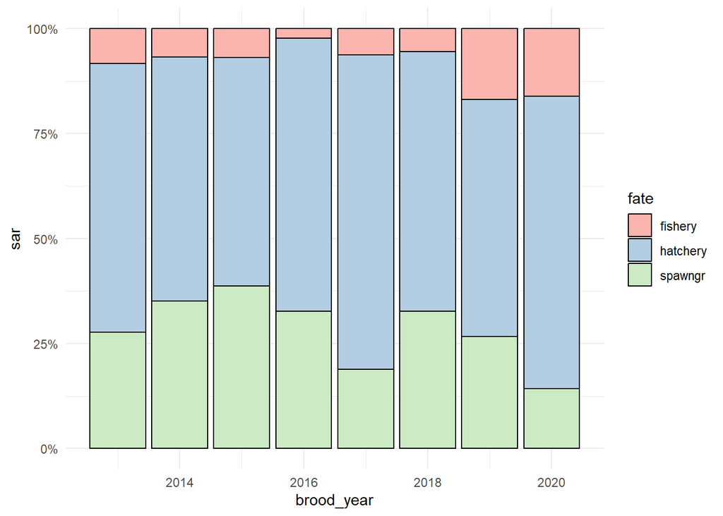

Figure 19: Proportion-at-fate of the calculated smolt-adult-return across brood years.

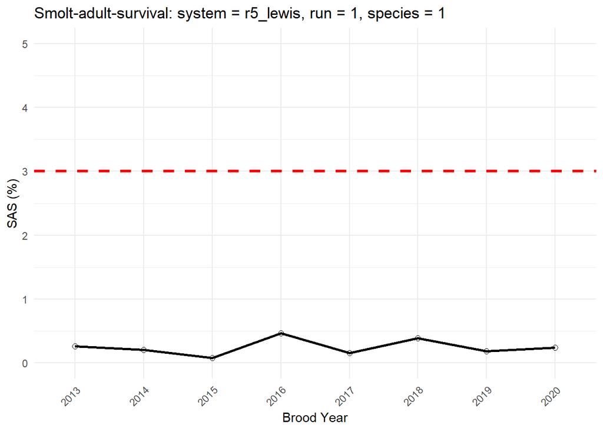

Figure 20: Smolt-adult-survival (SAS) calculated from fate-specific smolt-adult-return relative to a general SAS target for the queried species (red-dashed line).

```r
if(params$sp=="1"){sas_threshold <-3}

prop_at_fate <-aggregate(cbind(event_released,number_cwt_estimated)~fate+brood_year, data=sar_df_fit, FUN=sum)
prop_at_fate$sar <-prop_at_fate$number_cwt_estimated/prop_at_fate$event_released

ggplot(prop_at_fate, aes(x = brood_year, y = sar, fill = fate)) +
  geom_col(colour = "black", position = "fill") +
  scale_y_continuous(labels = scales::percent) +
  scale_fill_brewer(palette = "Pastel1")

sas_df <-sar_df %>% aggregate(number_cwt_estimated~brood_year+tag_code+event_released, data=., FUN=sum) %>%
                     aggregate(cbind(event_released,number_cwt_estimated)~brood_year, data=., FUN=sum)
sas_df$sas <-sas_df$number_cwt_estimated/sas_df$event_released

ggplot(data=sas_df, aes(x=as.factor(brood_year), y=sas*100, group=1))+
    geom_line(fill="black", size=1)+
    geom_point(pch=21,size=2)+
    geom_hline(yintercept=sas_threshold, color="red",linetype=2, size=1.2)+
    scale_y_continuous(limits=c(0,5), breaks=c(seq(0,5,1))) +
    # facet_wrap(.~run, ncol=1)+
    labs(x = "Brood Year", y = "SAS (%)", title = paste0("Smolt-adult-survival: system = ",params$system, ", run = ", params$run, ", species = ", params$sp))+
    theme(axis.text.x = element_text(angle = 45, hjust = 1))
```

## References

Independent Scientific Advisory Board (ISAB). 2025. Challenges and opportunities for improved estimation, interpretation, and use of smolt-to-adult return (SAR) and survival (SAS) metrics for salmon and steelhead in the Columbia River Basin. Report ISAB 2025-1. Northwest Power and Conservation Council, Portland, Oregon.

Quinn, T.P. 2018. The behavior and ecology of Pacific salmon and trout. Second Edition. University of Washington Press. ISBN: 9780295743332.